# The Highest Polish Football League (all time) PCA and Clustering

Piotr Wieczorek

2023-09-27

## Goal of the project

#### This Project aims to conduct PCA Analysis and K-means clustering on data regarding top football division of the 1927 - 2022/2023 seasons in Poland. Keep in mind that it is historical data and some teams that were taken into account do not exist today or represent regions that belong to other countries.

## Libraries

```r
library(readr)
library(factoextra)
library(tidyverse)
library(psych)
library(kableExtra)
library(ggrepel)
```

## Reading and cleaning the data

```r
df <- read_csv("ekstraklasa.csv")
```

```r
df
```

```
## # A tibble: 86 × 13
##     ...1 ranking name    seaso…¹ first…² match…³ total…⁴ total…⁵ total…⁶ total…⁷
##    <dbl>   <dbl> <chr>     <dbl> <chr>     <dbl>   <dbl>   <dbl>   <dbl>   <dbl>
##  1     0       1 Legia …      86 15         2400    3482    1186     591     623
##  2     1       2 Wisła …      82 14[1]      2232    2927     984     559     688
##  3     2       3 Górnik…      65 14         1914    2453     809     545     560
##  4     3       4 Ruch C…      77 13[1]      2070    2428     841     555     673
##  5     4       5 Lech P…      62 8          1818    2366     743     500     575
##  6     5       6 ŁKS Łó…      66 2          1756    1785     604     480     672
##  7     6       7 Pogoń …      50 0          1515    1677     509     430     576
##  8     7       8 Śląsk …      44 2          1371    1591     485     407     479
##  9     8       9 Widzew…      36 4          1109    1403     436     344     329
## 10     9      10 Zagłęb…      34 2          1091    1401     400     306     385
## # … with 76 more rows, 3 more variables: total_goals <dbl>,
## #   total_goals_conceded <dbl>, total_goals_diff <dbl>, and abbreviated
## #   variable names ¹season_count, ²first_place_count, ³matches_played,
## #   ⁴total_points, ⁵total_wins, ⁶total_draws, ⁷total_loses
```

```r
df$first_place_count <- sub("\\[.*$", "", df$first_place_count)
```

```r
df <- df[,c(2:13)]
```

```r
head(df)
```

```
## # A tibble: 6 × 12
##   ranking name   seaso…¹ first…² match…³ total…⁴ total…⁵ total…⁶ total…⁷ total…⁸
##     <dbl> <chr>    <dbl> <chr>     <dbl>   <dbl>   <dbl>   <dbl>   <dbl>   <dbl>
## 1       1 Legia…      86 15         2400    3482    1186     591     623    3999
## 2       2 Wisła…      82 14         2232    2927     984     559     688    3585
## 3       3 Górni…      65 14         1914    2453     809     545     560    2853
## 4       4 Ruch …      77 13         2070    2428     841     555     673    3109
## 5       5 Lech …      62 8          1818    2366     743     500     575    2541
## 6       6 ŁKS Ł…      66 2          1756    1785     604     480     672    2263
## # … with 2 more variables: total_goals_conceded <dbl>, total_goals_diff <dbl>,
## #   and abbreviated variable names ¹season_count, ²first_place_count,
## #   ³matches_played, ⁴total_points, ⁵total_wins, ⁶total_draws, ⁷total_loses,
## #   ⁸total_goals
```

```r
df <- df %>%
  mutate(name = as.factor(name),
         first_place_count = as.numeric(first_place_count))
```

```r
df
```

```
## # A tibble: 86 × 12
##    ranking name  seaso…¹ first…² match…³ total…⁴ total…⁵ total…⁶ total…⁷ total…⁸
##      <dbl> <fct>   <dbl>   <dbl>   <dbl>   <dbl>   <dbl>   <dbl>   <dbl>   <dbl>
##  1       1 Legi…      86      15    2400    3482    1186     591     623    3999
##  2       2 Wisł…      82      14    2232    2927     984     559     688    3585
##  3       3 Górn…      65      14    1914    2453     809     545     560    2853
##  4       4 Ruch…      77      13    2070    2428     841     555     673    3109
##  5       5 Lech…      62       8    1818    2366     743     500     575    2541
##  6       6 ŁKS …      66       2    1756    1785     604     480     672    2263
##  7       7 Pogo…      50       0    1515    1677     509     430     576    1809
##  8       8 Śląs…      44       2    1371    1591     485     407     479    1619
##  9       9 Widz…      36       4    1109    1403     436     344     329    1439
## 10      10 Zagł…      34       2    1091    1401     400     306     385    1371
## # … with 76 more rows, 2 more variables: total_goals_conceded <dbl>,
## #   total_goals_diff <dbl>, and abbreviated variable names ¹season_count,
## #   ²first_place_count, ³matches_played, ⁴total_points, ⁵total_wins,
## #   ⁶total_draws, ⁷total_loses, ⁸total_goals
```

#### Hypotheses:

- H0: These matrixes doesn’t diverge
- Ha: These matrixes diverge

```r
bartlett.test(x = df %>% select_if(is.numeric), nrow(df))
```

```
##
##  Bartlett test of homogeneity of variances
##
## data:  df %>% select_if(is.numeric)
## Bartlett's K-squared = 2088.7, df = 10, p-value < 2.2e-16
```

#### P-value is extremely low, therefore we reject the H0.

## PCA Analysis

### Scaling the data, getting the eigenvalues and eigenvectors

```r
pca <- prcomp(x = df %>% select_if(is.numeric), scale.=TRUE)
```

```r
pca
```

```
## Standard deviations (1, .., p=11):
##  [1] 3.1175704709 0.9894908346 0.4506366730 0.2452707945 0.1619055100
##  [6] 0.0916179433 0.0463799800 0.0350525831 0.0210362321 0.0012129040
## [11] 0.0002274722
##
## Rotation (n x k) = (11 x 11):
##                             PC1         PC2           PC3         PC4
## ranking               0.2589991  0.45913115 -0.8291724609 -0.18259221
## season_count         -0.3184851 -0.06590783 -0.1516316212 -0.02439520
## first_place_count    -0.2792683  0.45214377 -0.0147350663  0.82778775
## matches_played       -0.3190440 -0.08126556 -0.1228931668 -0.09644594
## total_points         -0.3191799  0.02811600  0.0004338514 -0.24497313
## total_wins           -0.3196685  0.06430510 -0.0271811528 -0.17954179
## total_draws          -0.3150173 -0.11862703 -0.1521316100 -0.10632782
## total_loses          -0.3099712 -0.23594177 -0.2177846249  0.02187239
## total_goals          -0.3196584  0.05442844 -0.0655277032 -0.04221305
## total_goals_conceded -0.3141933 -0.16585491 -0.2131015704  0.08345877
## total_goals_diff     -0.2267733  0.68460194  0.3913332299 -0.39843717
##                               PC5         PC6          PC7          PC8
## ranking               0.005128466 -0.03171745 -0.013022807  0.001779243
## season_count         -0.288114522  0.54002182 -0.056769054 -0.660876420
## first_place_count     0.137806801 -0.08068611 -0.047116799 -0.064791832
## matches_played        0.138740854  0.01206603 -0.150819407  0.053388669
## total_points          0.208637295 -0.69786068  0.009539054 -0.347684105
## total_wins           -0.047788400 -0.16764067  0.099385590 -0.248581358
## total_draws           0.757983790  0.36945519  0.203724541  0.190149227
## total_loses          -0.146406553 -0.05709055 -0.767857375  0.325330632
## total_goals          -0.317232024 -0.01050073  0.328914955  0.305555920
## total_goals_conceded -0.357946523 -0.08088596  0.450433108  0.302484261
## total_goals_diff     -0.090413251  0.19797072 -0.139603139  0.216000079
##                               PC9          PC10          PC11
## ranking              -0.006789155 -1.433659e-05 -1.272645e-05
## season_count         -0.236680778  2.103429e-03 -4.145922e-05
## first_place_count     0.014370575  1.061658e-04 -2.735276e-04
## matches_played        0.286218318  1.292017e-03  8.604000e-01
## total_points         -0.431048473  2.122249e-03 -3.192948e-04
## total_wins            0.794134197 -4.714234e-03 -3.577347e-01
## total_draws          -0.094155338 -1.873117e-04 -2.338373e-01
## total_loses          -0.056152383 -7.927476e-04 -2.775751e-01
## total_goals          -0.115285589 -7.570928e-01  2.001600e-03
## total_goals_conceded -0.099082744  6.184820e-01 -2.180884e-03
## total_goals_diff     -0.101144916  2.103735e-01 -9.360312e-04
```

### Variance

#### PCA1 and PCA2 capture ~97.26% of variance

```r
summary(pca)
```

```
## Importance of components:
##                           PC1     PC2     PC3     PC4     PC5     PC6     PC7
## Standard deviation     3.1176 0.98949 0.45064 0.24527 0.16191 0.09162 0.04638
## Proportion of Variance 0.8836 0.08901 0.01846 0.00547 0.00238 0.00076 0.00020
## Cumulative Proportion  0.8836 0.97258 0.99104 0.99651 0.99889 0.99965 0.99985
##                            PC8     PC9     PC10      PC11
## Standard deviation     0.03505 0.02104 0.001213 0.0002275
## Proportion of Variance 0.00011 0.00004 0.000000 0.0000000
## Cumulative Proportion  0.99996 1.00000 1.000000 1.0000000
```

### Scree plot

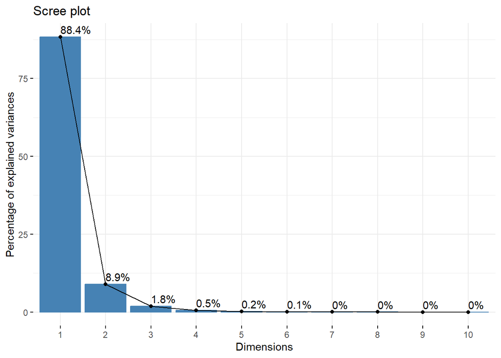

```r
fviz_eig(pca,addlabels = TRUE)
```

### Components Importance

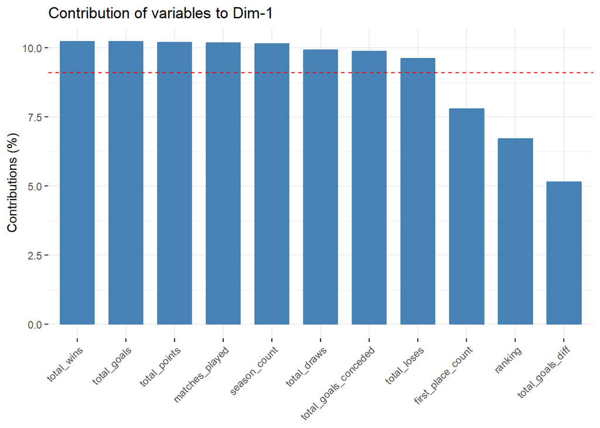

```r
fviz_contrib(pca,choice="var")
```

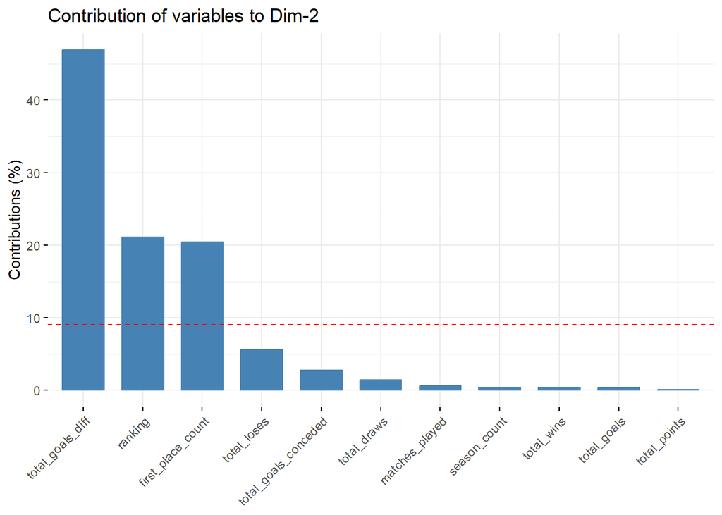

```r
fviz_contrib(pca,choice="var",axes=2)
```

```r
cor(df$ranking,df$first_place_count)
```

```
## [1] -0.506313
```

### PCA Biplot

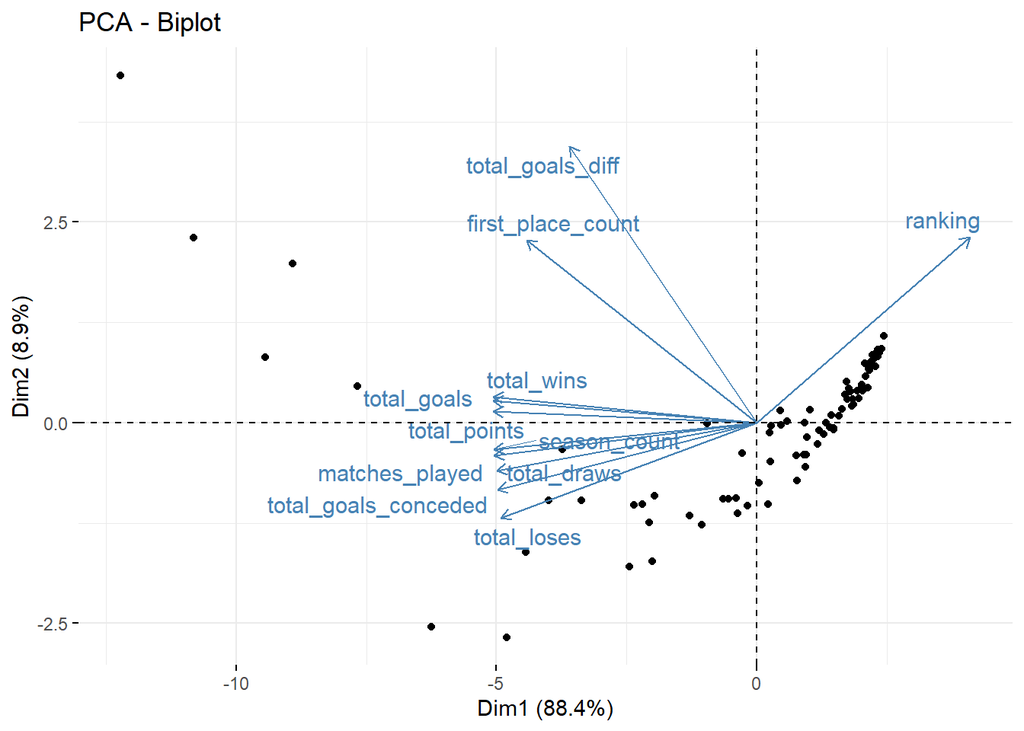

```r
fviz_pca_biplot(pca,label="var",repel = TRUE)
```

## Clustering

### Assigning name variable as a rowname

```r
df_clustering <- df %>%
  remove_rownames() %>%
  column_to_rownames(var="name")
```

```r
head(df_clustering)
```

```
##                ranking season_count first_place_count matches_played
## Legia Warszawa       1           86                15           2400
## Wisła Kraków         2           82                14           2232
## Górnik Zabrze        3           65                14           1914
## Ruch Chorzów         4           77                13           2070
## Lech Poznań          5           62                 8           1818
## ŁKS Łódź             6           66                 2           1756
##                total_points total_wins total_draws total_loses total_goals
## Legia Warszawa         3482       1186         591         623        3999
## Wisła Kraków           2927        984         559         688        3585
## Górnik Zabrze          2453        809         545         560        2853
## Ruch Chorzów           2428        841         555         673        3109
## Lech Poznań            2366        743         500         575        2541
## ŁKS Łódź               1785        604         480         672        2263
##                total_goals_conceded total_goals_diff
## Legia Warszawa                 2523             1476
## Wisła Kraków                   2685              900
## Górnik Zabrze                  2165              688
## Ruch Chorzów                   2662              447
## Lech Poznań                    2087              454
## ŁKS Łódź                       2429             -166
```

### Scaling the data

```r
df_clustering <- scale(df_clustering)
```

```r
head(df_clustering)
```

```
##                  ranking season_count first_place_count matches_played
## Legia Warszawa -1.702044     3.568993         4.4992468       3.525603
## Wisła Kraków   -1.661996     3.367395         4.1770693       3.225101
## Górnik Zabrze  -1.621948     2.510602         4.1770693       2.656292
## Ruch Chorzów   -1.581899     3.115397         3.8548917       2.935330
## Lech Poznań    -1.541851     2.359403         2.2440040       2.484576
## ŁKS Łódź       -1.501803     2.561002         0.3109388       2.373676
##                total_points total_wins total_draws total_loses total_goals
## Legia Warszawa     4.219522   4.402525    3.137074    2.587843    4.177218
## Wisła Kraków       3.436494   3.538044    2.926467    2.949042    3.673226
## Górnik Zabrze      2.767747   2.789112    2.834326    2.237757    2.782108
## Ruch Chorzów       2.732475   2.926059    2.900141    2.865688    3.093756
## Lech Poznań        2.645002   2.506658    2.538159    2.321111    2.402288
## ŁKS Łódź           1.825292   1.911792    2.406529    2.860132    2.063858
##                total_goals_conceded total_goals_diff
## Legia Warszawa             2.912946        6.4759936
## Wisła Kraków               3.154294        3.9489757
## Górnik Zabrze              2.379597        3.0188927
## Ruch Chorzów               3.120029        1.9615814
## Lech Poznań                2.263392        1.9922916
## ŁKS Łódź                   2.772905       -0.7277624
```

### Elbow plot

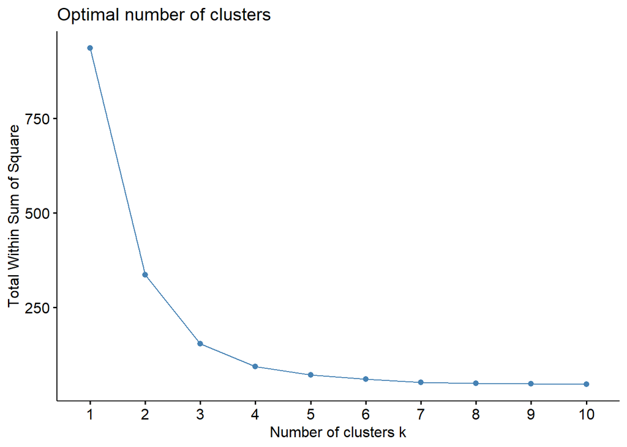

```r
fviz_nbclust(df_clustering,kmeans,method="wss")
```

### Fitting K-means algorithm on scaled data

```r
df_scaled_fit <- kmeans(df_clustering,3,nstart = 100)
```

### Cluster centers, Clustering vectors

```r
df_scaled_fit
```

```
## K-means clustering with 3 clusters of sizes 5, 62, 19
##
## Cluster means:
##      ranking season_count first_place_count matches_played total_points
## 1 -1.6219475    2.9843581        3.79045622      2.9653803    3.1602479
## 2  0.4773474   -0.4995532       -0.31782706     -0.5035451   -0.4789838
## 3 -1.1308315    0.8447635        0.03963139      0.8627839    0.7313557
##   total_wins total_draws total_loses total_goals total_goals_conceded
## 1  3.2324796   2.8672333   2.5922882   3.2257193            2.7660517
## 2 -0.4724347  -0.5066290  -0.5230442  -0.4739920           -0.5141537
## 3  0.6909764   0.8986753   1.0245946   0.6978373            0.9498562
##   total_goals_diff
## 1        3.4795470
## 2       -0.1941535
## 3       -0.2821169
##
## Clustering vector:
##                   Legia Warszawa                     Wisła Kraków
##                                1                                1
##                    Górnik Zabrze                     Ruch Chorzów
##                                1                                1
##                      Lech Poznań                         ŁKS Łódź
##                                1                                3
##                   Pogoń Szczecin                    Śląsk Wrocław
##                                3                                3
##                      Widzew Łódź                   Zagłębie Lubin
##                                3                                3
##                         Cracovia                     GKS Katowice
##                                3                                3
##                    Lechia Gdańsk                 Polonia Warszawa
##                                3                                3
##               Zagłębie Sosnowiec                    Polonia Bytom
##                                3                                3
##                      Stal Mielec            Jagiellonia Białystok
##                                3                                3
##                    Korona Kielce                 Szombierki Bytom
##                                3                                3
##                    Piast Gliwice                      Wisła Płock
##                                2                                3
##                     Warta Poznań                 Gwardia Warszawa
```

[output cut: 57 more lines]

```
##                        ŁTSG Łódź                     Śmigły Wilno
##                                2                                2
##                 Jutrzenka Kraków                      Lechia Lwów
##                                2                                2
##               Union-Touring Łódź              Puszcza Niepołomice
##                                2                                2
##
## Within cluster sum of squares by cluster:
## [1] 26.33614 61.93970 65.89161
##  (between_SS / total_SS =  83.5 %)
##
## Available components:
##
## [1] "cluster"      "centers"      "totss"        "withinss"     "tot.withinss"
## [6] "betweenss"    "size"         "iter"         "ifault"
```

### Adding data about clusters to df (the original dataframe without scaled data)

```r
df$clusters <- df_scaled_fit$cluster
```

```r
df %>%
  kable(align = "c") %>%
  kable_styling(position="center") %>%
  scroll_box(width = '100%', height = "500px")
```

ranking

name

season_count

first_place_count

matches_played

total_points

total_wins

total_draws

total_loses

total_goals

total_goals_conceded

total_goals_diff

clusters

1

Legia Warszawa

86

15

2400

3482

1186

591

623

3999

2523

1476

1

2

Wisła Kraków

82

14

2232

2927

984

559

688

3585

2685

900

1

3

Górnik Zabrze

65

14

1914

2453

809

545

560

2853

2165

688

1

4

Ruch Chorzów

77

13

2070

2428

841

555

673

3109

2662

447

1

5

Lech Poznań

62

8

1818

2366

743

500

575

2541

2087

454

1

6

ŁKS Łódź

66

2

1756

1785

604

480

672

2263

2429

-166

3

7

Pogoń Szczecin

50

0

1515

1677

509

430

576

1809

2025

-216

3

8

Śląsk Wrocław

44

2

1371

1591

485

407

479

1619

1670

-51

3

9

Widzew Łódź

36

4

1109

1403

436

344

329

1439

1291

148

3

10

Zagłębie Lubin

34

2

1091

1401

400

306

385

1371

1323

48

3

11

Cracovia

44

4

1163

1331

427

278

458

1632

1630

2

3

12

GKS Katowice

30

0

894

1030

321

286

287

1023

977

46

3

13

Lechia Gdańsk

31

0

879

1007

293

236

350

989

1152

-163

3

14

Polonia Warszawa

31

1

800

966

304

178

318

1165

1251

-86

3

15

Zagłębie Sosnowiec

36

0

987

918

322

267

398

1180

1330

-150

3

16

Polonia Bytom

35

2

889

879

289

272

328

1097

1139

-42

3

17

Stal Mielec

28

2

835

835

273

258

304

940

983

-43

3

18

Jagiellonia Białystok

20

0

661

822

228

180

253

793

922

-129

3

19

Korona Kielce

15

0

503

658

172

142

189

596

679

-83

3

20

Szombierki Bytom

25

1

702

645

235

180

287

875

999

-124

3

21

Piast Gliwice

13

1

447

632

173

113

161

548

541

7

2

22

Wisła Płock

16

0

516

620

168

124

224

613

759

-146

3

23

Warta Poznań

21

2

508

553

213

91

204

946

838

108

3

24

Gwardia Warszawa

23

0

572

539

195

149

228

682

764

-82

3

25

Odra Wodzisław Śląski

14

0

418

529

145

94

179

487

570

-83

2

26

Odra Opole

22

0

564

523

182

159

223

645

740

-95

3

27

Arka Gdynia

16

0

508

510

144

147

216

522

667

-145

2

28

Amica Wronki

11

0

332

498

135

93

104

452

370

82

2

29

GKS Bełchatów

12

0

375

486

130

96

149

422

463

-41

2

30

Dyskobolia Grodzisk Wielkopolski

10

0

293

441

124

69

100

420

357

63

2

31

Raków Częstochowa

8

1

271

392

112

65

94

340

321

19

2

32

Zawisza Bydgoszcz

14

0

430

376

126

98

206

461

651

-190

2

33

Garbarnia Kraków

15

1

315

306

121

64

130

561

561

0

2

34

Pogoń Lwów

13

0

273

304

130

44

99

537

439

98

2

35

Stomil Olsztyn

8

0

254

296

76

75

103

255

339

-84

2

36

Górnik Łęczna

8

0

257

276

70

66

121

260

391

-131

2

37

Stal Rzeszów

11

0

290

255

79

97

114

297

377

-80

2

38

Hutnik Kraków

7

0

234

254

75

81

78

299

284

15

2

39

Warszawianka

13

0

271

227

90

47

134

427

612

-185

2

40

Podbeskidzie Bielsko-Biała

6

0

201

222

54

60

87

225

310

-85

2

41

Olimpia Poznań

8

0

250

220

67

91

92

269

317

-48

2

42

Motor Lublin

9

0

274

220

70

92

112

259

372

-113

2

43

AKS Chorzów

10

0

192

196

80

36

76

336

307

29

2

44

Bałtyk Gdynia

7

0

210

186

64

61

85

184

247

-56

2

45

ROW Rybnik

7

0

198

165

50

65

83

165

233

-78

2

46

Bruk-Bet Termalica Nieciecza

4

0

145

156

39

39

67

149

227

-78

2

47

Górnik Wałbrzych

6

0

180

154

52

55

73

194

246

-52

2

48

Zagłębie Wałbrzych

6

0

160

142

50

42

68

131

166

-35

2

49

Czarni Lwów

7

0

164

141

56

29

79

265

326

-61

2

50

Górnik Radlin

8

0

162

136

50

36

76

193

280

-87

2

51

Sokół Pniewy

4

0

136

130

36

42

58

128

190

-62

2

52

Polonia Bydgoszcz

7

0

156

129

47

35

74

186

296

-110

2

53

Radomiak Radom

3

0

98

117

31

32

35

105

113

-8

2

54

Ruch Radzionków

3

0

90

109

30

19

41

105

135

-30

2

55

Stal Stalowa Wola

4

0

132

103

32

44

56

113

173

-60

2

56

1. FC Katowice

3

0

78

88

39

10

29

164

143

21

2

57

GKS Tychy

3

0

90

86

28

30

32

105

113

-8

2

58

Klub Turystów Łódź

3

0

78

73

31

11

36

134

161

-27

2

59

KSZO Ostrowiec Świętokrzyski

3

0

92

71

18

17

57

73

147

-74

2

60

Siarka Tarnobrzeg

3

0

102

65

19

24

59

88

169

-81

2

61

Arkonia Szczecin

4

0

88

64

20

24

44

100

166

-66

2

62

Miedź Legnica

2

0

71

63

14

21

36

73

120

-47

2

63

Śląsk Świętochłowice

3

0

66

45

19

7

40

84

166

-82

2

64

Lechia/Olimpia Gdańsk

1

0

34

40

11

7

16

39

59

-20

2

65

Unia Racibórz

2

0

52

38

14

10

28

77

126

-49

2

66

Hasmonea Lwów

2

0

54

38

14

10

30

98

149

-51

2

67

Wawel Kraków

2

0

32

37

13

11

8

50

36

14

2

68

Igloopol Dębica

2

0

64

37

9

19

36

43

121

-78

2

69

22 Strzelec Siedlce

3

0

64

36

14

8

42

84

169

-85

2

70

Sandecja Nowy Sącz

1

0

37

33

6

15

16

34

54

-20

2

71

Szczakowianka Jaworzno

1

0

30

32

8

8

14

40

54

-14

2

72

RKS Radomsko

1

0

28

31

7

10

11

23

34

-11

2

73

TKS Toruń

2

0

54

30

13

4

37

84

185

-101

2

74

Podgórze Kraków

2

0

42

27

11

5

26

56

103

-47

2

75

Górnik Polkowice

1

0

26

23

6

5

15

17

37

-20

2

76

Tarnovia Tarnów

1

0

26

22

10

2

14

42

48

-6

2

77

Świt Nowy Dwór Mazowiecki

1

0

26

22

5

7

14

21

42

-21

2

78

Rymer Niedobczyce

1

0

26

19

8

3

15

45

64

-19

2

79

GKS Jastrzębie-Zdrój

1

0

30

19

8

8

14

24

43

-19

2

80

Dąb Katowice

2

0

36

14

7

0

29

29

97

-68

2

81

ŁTSG Łódź

1

0

22

12

3

6

13

25

67

-42

2

82

Śmigły Wilno

1

0

18

11

5

1

12

29

50

-21

2

83

Jutrzenka Kraków

1

0

26

11

3

5

18

41

82

-41

2

84

Lechia Lwów

1

0

22

11

5

1

16

23

66

-43

2

85

Union-Touring Łódź

1

0

12

3

1

1

10

15

51

-36

2

86

Puszcza Niepołomice

0

0

0

0

0

0

0

0

0

0

2

### To the 1st cluster belong

```r
df %>%
  filter(clusters == 1) %>%
  select(c("name","clusters"))
```

```
## # A tibble: 5 × 2
##   name           clusters
##   <fct>             <int>
## 1 Legia Warszawa        1
## 2 Wisła Kraków          1
## 3 Górnik Zabrze         1
## 4 Ruch Chorzów          1
## 5 Lech Poznań           1
```

### To the 2nd cluster belong

```r
df %>%
  filter(clusters == 2) %>%
  select(c("name","clusters"))
```

```
## # A tibble: 62 × 2
##    name                             clusters
##    <fct>                               <int>
##  1 Piast Gliwice                           2
##  2 Odra Wodzisław Śląski                   2
##  3 Arka Gdynia                             2
##  4 Amica Wronki                            2
##  5 GKS Bełchatów                           2
##  6 Dyskobolia Grodzisk Wielkopolski        2
##  7 Raków Częstochowa                       2
##  8 Zawisza Bydgoszcz                       2
##  9 Garbarnia Kraków                        2
## 10 Pogoń Lwów                              2
## # … with 52 more rows
```

### To the 3rd cluster belong

```r
df %>%
  filter(clusters == 3) %>%
  select(c("name","clusters"))
```

```
## # A tibble: 19 × 2
##    name                  clusters
##    <fct>                    <int>
##  1 ŁKS Łódź                     3
##  2 Pogoń Szczecin               3
##  3 Śląsk Wrocław                3
##  4 Widzew Łódź                  3
##  5 Zagłębie Lubin               3
##  6 Cracovia                     3
##  7 GKS Katowice                 3
##  8 Lechia Gdańsk                3
##  9 Polonia Warszawa             3
## 10 Zagłębie Sosnowiec           3
## 11 Polonia Bytom                3
## 12 Stal Mielec                  3
## 13 Jagiellonia Białystok        3
## 14 Korona Kielce                3
## 15 Szombierki Bytom             3
## 16 Wisła Płock                  3
## 17 Warta Poznań                 3
## 18 Gwardia Warszawa             3
## 19 Odra Opole                   3
```

```r
options(ggrepel.max.overlaps = Inf)
```

### Clustering Plot

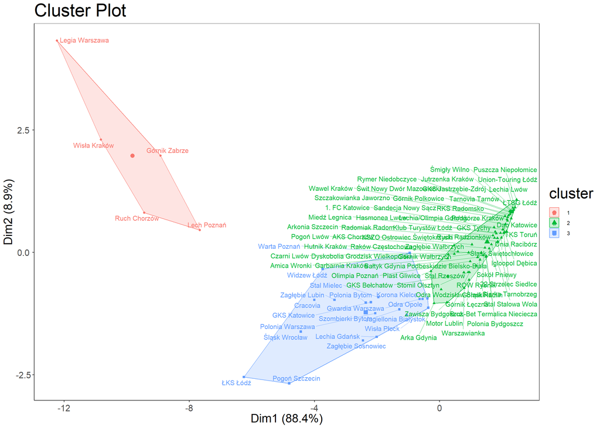

```r
fviz_cluster(list(data=df_clustering,cluster= df_scaled_fit$cluster),repel = TRUE,ggtheme = theme_bw(),geom = c("text","point"))+
labs(title = "Cluster Plot") +
  theme(axis.text.x = element_text(hjust = 0.5, vjust = 0.5, size=15),
        axis.title.x =element_text(size=20),
        axis.text.y = element_text(hjust = 0.5, vjust = 0.5, size=15),
        axis.title.y =element_text(size=20),
        panel.grid.major = element_blank(),
        panel.grid.minor = element_blank(),
        axis.line = element_line(colour = "black"),
        strip.text = element_text(size=25),
        title = element_text(size=25))
```

```r
pca
```

```
## Standard deviations (1, .., p=11):
##  [1] 3.1175704709 0.9894908346 0.4506366730 0.2452707945 0.1619055100
##  [6] 0.0916179433 0.0463799800 0.0350525831 0.0210362321 0.0012129040
## [11] 0.0002274722
##
## Rotation (n x k) = (11 x 11):
##                             PC1         PC2           PC3         PC4
## ranking               0.2589991  0.45913115 -0.8291724609 -0.18259221
## season_count         -0.3184851 -0.06590783 -0.1516316212 -0.02439520
## first_place_count    -0.2792683  0.45214377 -0.0147350663  0.82778775
## matches_played       -0.3190440 -0.08126556 -0.1228931668 -0.09644594
## total_points         -0.3191799  0.02811600  0.0004338514 -0.24497313
## total_wins           -0.3196685  0.06430510 -0.0271811528 -0.17954179
## total_draws          -0.3150173 -0.11862703 -0.1521316100 -0.10632782
## total_loses          -0.3099712 -0.23594177 -0.2177846249  0.02187239
## total_goals          -0.3196584  0.05442844 -0.0655277032 -0.04221305
## total_goals_conceded -0.3141933 -0.16585491 -0.2131015704  0.08345877
## total_goals_diff     -0.2267733  0.68460194  0.3913332299 -0.39843717
##                               PC5         PC6          PC7          PC8
## ranking               0.005128466 -0.03171745 -0.013022807  0.001779243
## season_count         -0.288114522  0.54002182 -0.056769054 -0.660876420
## first_place_count     0.137806801 -0.08068611 -0.047116799 -0.064791832
## matches_played        0.138740854  0.01206603 -0.150819407  0.053388669
## total_points          0.208637295 -0.69786068  0.009539054 -0.347684105
## total_wins           -0.047788400 -0.16764067  0.099385590 -0.248581358
## total_draws           0.757983790  0.36945519  0.203724541  0.190149227
## total_loses          -0.146406553 -0.05709055 -0.767857375  0.325330632
## total_goals          -0.317232024 -0.01050073  0.328914955  0.305555920
## total_goals_conceded -0.357946523 -0.08088596  0.450433108  0.302484261
## total_goals_diff     -0.090413251  0.19797072 -0.139603139  0.216000079
##                               PC9          PC10          PC11
## ranking              -0.006789155 -1.433659e-05 -1.272645e-05
## season_count         -0.236680778  2.103429e-03 -4.145922e-05
## first_place_count     0.014370575  1.061658e-04 -2.735276e-04
## matches_played        0.286218318  1.292017e-03  8.604000e-01
## total_points         -0.431048473  2.122249e-03 -3.192948e-04
## total_wins            0.794134197 -4.714234e-03 -3.577347e-01
## total_draws          -0.094155338 -1.873117e-04 -2.338373e-01
## total_loses          -0.056152383 -7.927476e-04 -2.775751e-01
## total_goals          -0.115285589 -7.570928e-01  2.001600e-03
## total_goals_conceded -0.099082744  6.184820e-01 -2.180884e-03
## total_goals_diff     -0.101144916  2.103735e-01 -9.360312e-04
```